# Ultramafic and Mafic Rocks

Dr. Ahmad Redaa

20-10-2025

# 1. Introduction

**Ultramafic and mafic rocks** represent the **magnesium- and iron-rich end** of the igneous spectrum.

| Rock Type | Silica (SiO₂ wt%) | Fe–Mg Content | Typical Minerals | Example |
| --- | --- | --- | --- | --- |
| **Ultramafic** | < 45% | Very high | Olivine, Pyroxene | Peridotite |
| **Mafic** | 45–52% | High | Pyroxene, Plagioclase (Ca-rich) | Basalt, Gabbro |

# 2. Chemical Characteristics

| Oxide | Ultramafic (%) | Mafic (%) | Trend |
| --- | --- | --- | --- |
| SiO₂ | 35–45 | 45–52 | ↑ with differentiation |
| MgO | 30–45 | 5–12 | ↓ with differentiation |
| FeO / Fe₂O₃ | 8–12 | 8–12 | Variable |
| Al₂O₃ | < 5 | 12–18 | ↑ in mafic rocks |
| CaO | 2–10 | 8–12 | ↑ in mafic |
| Na₂O + K₂O | < 1 | 2–5 | ↑ strongly toward felsic |

# 3. Mineralogical Composition

### Ultramafic Rocks

- Dominated by **ferromagnesian silicates**:
  - **Olivine (Fo–Fa series)**
  - **Orthopyroxene (Enstatite–Hypersthene)**
  - **Clinopyroxene (Diopside–Augite)**
  - Minor **spinel**, **chromite**, or **amphibole**

### Ultramafic Rock Types

| Rock | Major Minerals | Texture | Origin |
| --- | --- | --- | --- |
| **Peridotite** | Olivine + Pyroxene | Coarse | Mantle / lower crust |
| **Dunite** | >90% Olivine | Granular | Mantle cumulate |
| **Harzburgite** | Olivine + Orthopyroxene | Granular | Residual mantle |
| **Lherzolite** | Olivine + Opx + Cpx | Equigranular | Upper mantle |

### **Mafic Rocks**

- Dominated by **pyroxene** and **Ca-rich plagioclase**, minor olivine and Fe–Ti oxides.
- **Silica-rich compared to ultramafic**, typically 45–52 wt%.

| Rock | Major Minerals | Texture | Occurrence |
| --- | --- | --- | --- |
| **Basalt** | Plagioclase + Pyroxene ± Olivine | Fine-grained | Extrusive (oceanic crust) |
| **Gabbro** | Plagioclase + Pyroxene | Coarse-grained | Intrusive equivalent of basalt |
| **Dolerite (Diabase)** | Plagioclase + Pyroxene | Medium-grained | Dike/sill intrusive |
| **Norite / Troctolite** | Plagioclase + Opx / Olivine | Coarse | Layered intrusions |

# 4. Formation and Tectonic Settings

### Ultramafic Rocks

- Represent **mantle material** or **cumulates** from early crystallization.
- **Primary settings:**
  - Mantle peridotite (upper mantle)
  - Layered mafic–ultramafic intrusions (e.g., Bushveld, South Africa)
  - Ophiolite complexes (emplaced oceanic lithosphere)
  - Alpine-type peridotites (obducted mantle slices)

### Mafic Rocks

- Represent **primary melts** from partial melting of the mantle.
- **Common settings:**
  - Mid-ocean ridges (MORB)
  - Island arcs (calc-alkaline basalts)
  - Intraplate settings (OIB)
  - Large igneous provinces (flood basalts)

# 5. Petrogenesis

- **Partial melting** of mantle peridotite produces **basaltic magma**.
- **Fractional crystallization** of basaltic magma → gabbroic cumulates.
- Residual mantle after extraction becomes **harzburgite** or **dunite**.

**Simplified sequence:**

> Peridotite (mantle) → Partial melt → Basalt magma → Crystallization → Gabbro cumulate

# 6. Ophiolite Complexes

**Definition:**  
> A **section of oceanic lithosphere and upper mantle** thrust onto continental crust during plate convergence.

**Significance:**  
Natural windows into **oceanic crustal structure** and **mantle composition**.

### Ophiolite Sequence

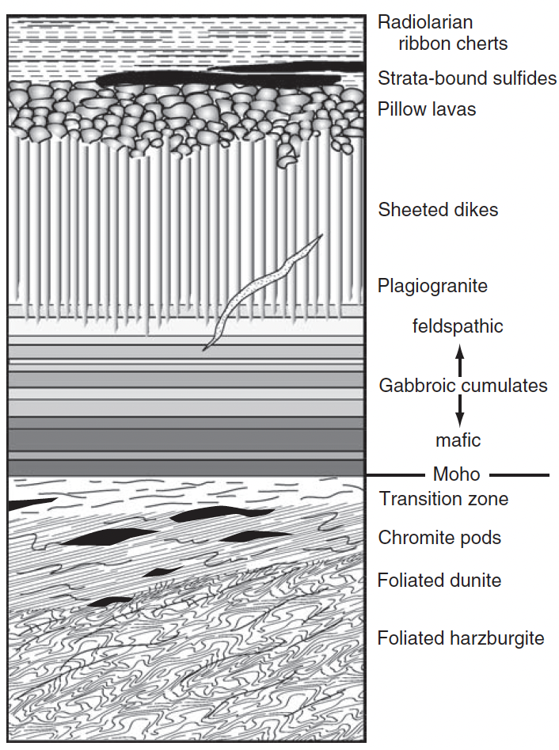

Ophiolite sequence diagram illustrating typical oceanic crustal and upper mantle sections.

Source: [Winter, J. (2014)](https://www.whitman.edu/geology/winter/Winter_Principles%20of%20Igneous%20and%20Metamorphic%20Petrology%20by%20JOHN%20D.%20WINTER-1.pdf)

| Unit | Rock Type | Description |
| --- | --- | --- |
| **1. Pillow lavas** | Basalt | Submarine extrusive top layer |
| **2. Sheeted dike complex** | Dolerite | Vertical feeder dikes |
| **3. Gabbroic layer** | Gabbro, Norite | Coarse-grained intrusive rocks |
| **4. Ultramafic cumulates** | Dunite, Pyroxenite | Early crystallization products |
| **5. Mantle peridotite** | Harzburgite, Lherzolite | Residual mantle rock |

### Example: The Oman Ophiolite (Semail)

- One of the **best-preserved ophiolites** globally.
- Represents complete **oceanic crust + upper mantle** section.
- Displays clear cumulate layering, dike complexes, and tectonic peridotite.
- Provides insights into **seafloor spreading** and **magma evolution**.

# 7. Geochemical Characteristics of Ophiolitic Mafic Rocks

| Setting | SiO₂ (%) | TiO₂ (%) | FeO (%) | MgO (%) | Signature |
| --- | --- | --- | --- | --- | --- |
| **MORB-type** | 48–52 | 1.5–2.5 | 8–12 | 6–10 | Low-K, flat REE pattern |
| **Island-arc type** | 50–55 | 0.5–1.0 | 6–10 | 5–8 | LREE-depleted, subduction signatures |
| **Back-arc type** | 50–53 | 1.0–2.0 | 7–11 | 6–9 | Transitional MORB–arc |

# 8. Textures and Field Relations

| Texture | Description | Example |
| --- | --- | --- |
| **Cumulus texture** | Crystals accumulated from magma | Layered gabbro |
| **Ophitic / Subophitic** | Plagioclase enclosed by pyroxene | Dolerite |
| **Porphyritic** | Large phenocrysts in fine matrix | Basalt |
| **Serpentinization** | Hydration of olivine → serpentine | Peridotite alteration |

# 9. Economic Importance

- **Chromite deposits** in dunites and harzburgites (layered intrusions, ophiolites)
- **Nickel–copper–PGE** deposits in mafic–ultramafic complexes
- **Magnesite and asbestos** from serpentinized peridotites